# House Prices in New York

Abtahee Islam

## Introduction

- **Topic: Which property and neighborhood features best predict house prices in New York?**
- **Motivation:** New York has one of the most expensive housing markets in the world. Understanding its pricing system helps buyers and investors make smarter decisions.
- **Goal:** Identify the key variables that influence house prices and compare how their effects differ across several predictive models.
- **Why it matters:** Property traits are complex! They jointly affect metrics like affordability and urban development.

## Dataset Overview

- **Data source:** New York housing sales dataset (`housing-prices-ge19.txt`)
- **Size:** 1734 observations, 17 variables
- **Response variable:** Sale price of each property (USD)
- **Predictor variables:**
  - *Property features:* `Lot.Size`, `Living.Area`, `Bedrooms`, `Bathrooms`, `Fireplaces`, `Age`, `Rooms`
  - *Neighborhood features:* `Pct.College` (college educated residents %), `Waterfront`, `Central.Air`, `Sewer.Type`, `Fuel.Type`, `Land.Value`
- **Main question:** How much do location and property attributes explain prices?

## Initial Observations

- **Median values of predictor variables:**
  - *Price* ≈ $189,700
  - *Lot size* ≈ 0.37 acres
  - *Area* ≈ 1632 square feet
  - *Number of bedrooms* ≈ 3
  - *Number of bathrooms* ≈ 2

```
# A tibble: 1 × 5
  median_price median_lot median_area median_beds median_baths
         <dbl>      <dbl>       <dbl>       <dbl>        <dbl>
1       189700       0.37        1632           3            2
```

## Distribution of House Prices

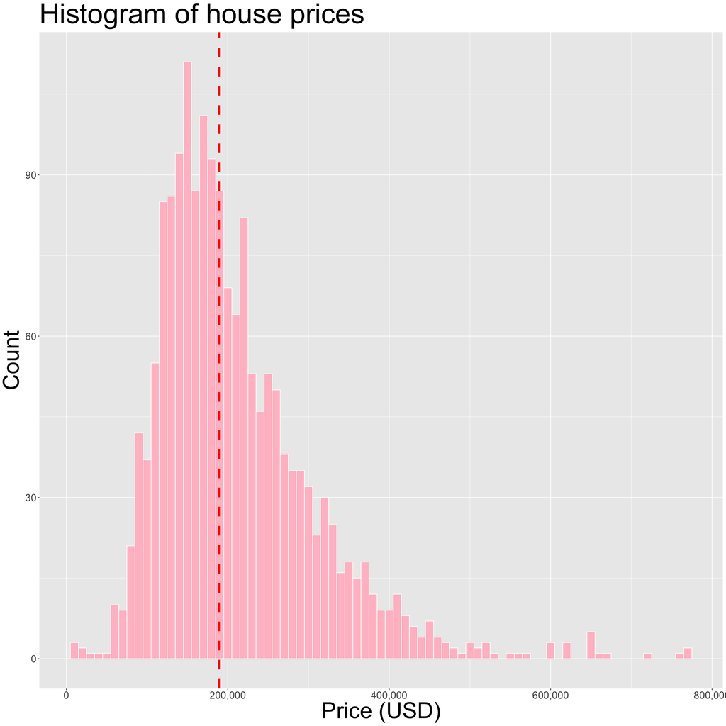

- Prices are **right-skewed**; most homes are in lower ranges.
- **Several high-value outliers** above $500,000.
- **Log transformation** recommended to stabilize variance.
- **Outlier handling** improves model robustness.

## Exploring Key Predictors of House Prices

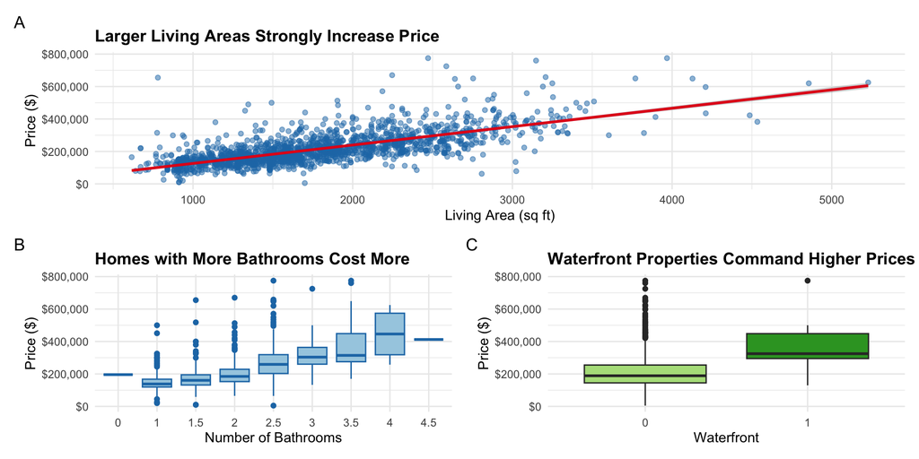

## *In our exploratory data analysis (EDA), we examined relationships between key predictors and house prices.*

## Data Cleaning & Transformation

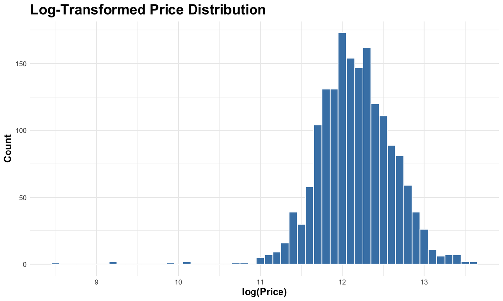

## Correlation Matrix & Predictor Strength

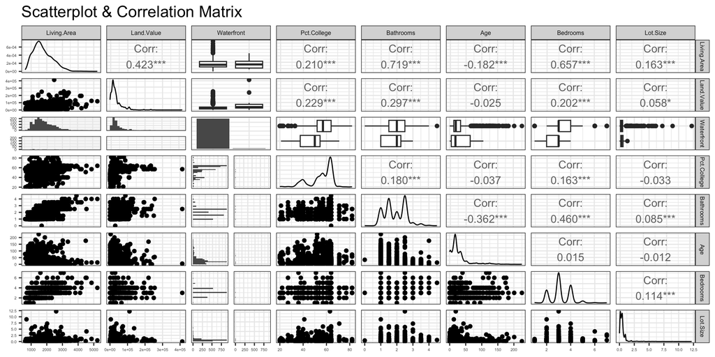

### List R² of the variables(simple linear regression)

```
     Variable  R_Squared
1 Living.Area 0.50906151
5   Bathrooms 0.35728862
2  Land.Value 0.33718069
7    Bedrooms 0.16201240
4 Pct.College 0.03992573
6         Age 0.03946426
8    Lot.Size 0.02476939
3  Waterfront 0.02372140
```

### Multiple Linear Regression Testing:

```
Call:
lm(formula = Price_1K ~ Living.Area + Land.Value + Age + Pct.College,
    data = data_transformed)

Residuals:
    Min      1Q  Median      3Q     Max
-232.42  -36.34   -5.16   26.99  469.83

Coefficients:
              Estimate Std. Error t value Pr(>|t|)
(Intercept)  3.189e+01  8.913e+00   3.578 0.000356 ***
Living.Area  8.752e-02  2.697e-03  32.450  < 2e-16 ***
Land.Value   9.722e-04  4.727e-05  20.567  < 2e-16 ***
Age         -2.969e-01  5.039e-02  -5.893 4.56e-09 ***
Pct.College  1.947e-02  1.482e-01   0.131 0.895518
---
Signif. codes:  0 '***' 0.001 '**' 0.01 '*' 0.05 '.' 0.1 ' ' 1

Residual standard error: 61.49 on 1729 degrees of freedom
Multiple R-squared:  0.6116,    Adjusted R-squared:  0.6107
F-statistic: 680.8 on 4 and 1729 DF,  p-value: < 2.2e-16
```

- Median is -5.16, which is very close to 0.
- Housing prices is strongly related with living area(0.71) and land value (0.58) and has a weak negative correlation with age(-0.19).
- The variable can explain 61% of changes of the housing prices.

## Diagnostic Plots and Assumption check

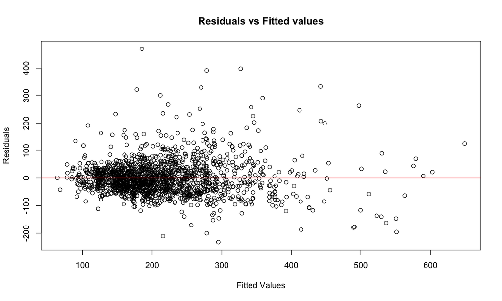

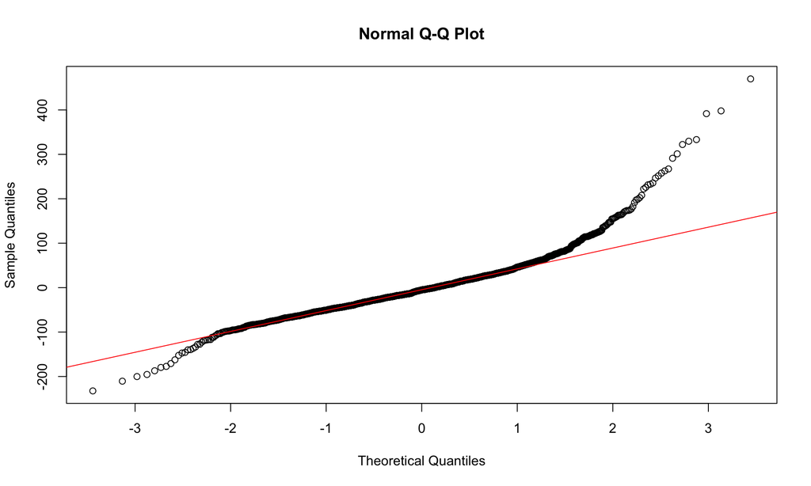

- Residual Plot: Distribution is relatively constant, the variance homogeneity and linear relationship assumptions are mostly satisfied.
- Q-Q plot: The middle part is normal, but there is a significant deviation in the right tail.

## Random Forest Model

```
Call:
 randomForest(formula = Price ~ Bathrooms, data = data, ntree = 100)
               Type of random forest: regression
                     Number of trees: 100
No. of variables tried at each split: 1

          Mean of squared residuals: 6164806291
                    % Var explained: 36.49
```

```
  Bathrooms Predicted_Price Price_Growth
1       1.0          147011           NA
2       1.5          167947         14.2
3       2.0          201259         19.8
4       2.5          268170         33.2
5       3.0          321806         20.0
6       3.5          381825         18.7
7       4.0          454084         18.9
```

- Non-linear approach captures relationship between bathroom and housing prices.
- Prices increase with bathroom count but not linearly.
- The price increase is most significant from 1.5 to 2.5 bathrooms, with diminishing returns starting with 3 bathrooms, indicating diminishing marginal returns.

## Ranking Key Predictors

Predictors ranked by |t-statistic|

| Predictor | t_statistic |
| --- | --- |
| Living Area | 32.450 |
| Land Value | 20.567 |
| Age | 5.893 |
| Pct.College | 0.131 |

- Predictors are ranked by the absolute value of the test statistics from the multiple linear regression model.
- Higher |t| values indicate stronger evidence that a variable affects price.
- **Land Value** and **Living Area** are the strongest predictors which show that property size and land worth are the main drivers of New York housing prices.

## Predicted vs Actual Prices

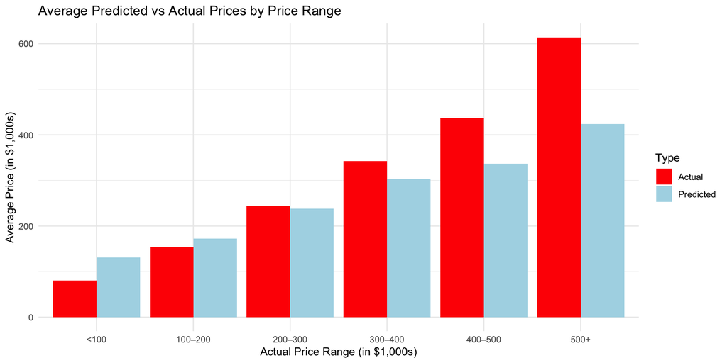

## Model Limitations

- The **Multiple Linear Regression model** assumes linear relationship between predictors and prices which does not hold in real-world markets as prices usually behave non-linearly.
- The **Random Forest model** captures non-linear relationships but it lacks transparency, making it difficult to interpret how each variable affects prices.
- Both models only used selected predictors, so not including other variables may reduce accuracy and leave out important factors influencing price.

## Key Insights

### What It Means

- Price drivers center on **home size** and **land worth**
- **Neighborhood quality** adds value, but physical traits dominate
- Linear captures main trends; RF uncovers **non-linearities**

## Practical Implications

### For Buyers

- Use key attributes to **benchmark fair value**
- Spot listings that are **over-/under-priced**
- Value-add: increase usable space / modernize age-sensitive features

### For Developers

- Prioritize **land acquisition** & **usable living area**
- Extra rooms/baths beyond needs → **diminishing returns**
- Newer construction tends to price higher (mitigate “age” effect)

## Conclusion

### Key Takeaways

- Core economics: **scale + land**
- **Statistics + ML** → accuracy **and** interpretability
- Results inform buying, development, and investment choices

### Future Work

- Add **geo-coordinates** for spatial effects
- Enrich **income / crime / school quality** variables
- Include **time trends**; cross-city comparisons